# Used_for_website_2

```python
# @title
#importing required libraries

import numpy as np
import pandas as pd
import matplotlib.pyplot as plt
%matplotlib inline
import seaborn as sns
from sklearn import metrics
import warnings
warnings.filterwarnings('ignore')
```

```python
# @title

from google.colab import drive
drive.mount('/content/drive')
```

## 2. Familiarizing with Data & EDA:

In this step, few dataframe methods are used to look into the data and its features.

```python
# @title
data = pd.read_csv('/content/drive/MyDrive/Colab Notebooks/Dataset/phishing.csv')
```

```python
# @title
data.head(5)
```

|  | Index | UsingIP | LongURL | ShortURL | Symbol@ | Redirecting// | PrefixSuffix- | SubDomains | HTTPS | DomainRegLen | ... | UsingPopupWindow | IframeRedirection | AgeofDomain | DNSRecording | WebsiteTraffic | PageRank | GoogleIndex | LinksPointingToPage | StatsReport | class |
| --- | --- | --- | --- | --- | --- | --- | --- | --- | --- | --- | --- | --- | --- | --- | --- | --- | --- | --- | --- | --- | --- |
| 0 | 0 | 1 | 1 | 1 | 1 | 1 | -1 | 0 | 1 | -1 | ... | 1 | 1 | -1 | -1 | 0 | -1 | 1 | 1 | 1 | -1 |
| 1 | 1 | 1 | 0 | 1 | 1 | 1 | -1 | -1 | -1 | -1 | ... | 1 | 1 | 1 | -1 | 1 | -1 | 1 | 0 | -1 | -1 |
| 2 | 2 | 1 | 0 | 1 | 1 | 1 | -1 | -1 | -1 | 1 | ... | 1 | 1 | -1 | -1 | 1 | -1 | 1 | -1 | 1 | -1 |
| 3 | 3 | 1 | 0 | -1 | 1 | 1 | -1 | 1 | 1 | -1 | ... | -1 | 1 | -1 | -1 | 0 | -1 | 1 | 1 | 1 | 1 |
| 4 | 4 | -1 | 0 | -1 | 1 | -1 | -1 | 1 | 1 | -1 | ... | 1 | 1 | 1 | 1 | 1 | -1 | 1 | -1 | -1 | 1 |

5 rows × 32 columns

```python
# @title
#Shape of dataframe

data.shape
```

```
(11054, 32)
```

```python
# @title
#Listing the features of the dataset
data.columns
```

```
Index(['Index', 'UsingIP', 'LongURL', 'ShortURL', 'Symbol@', 'Redirecting//',
       'PrefixSuffix-', 'SubDomains', 'HTTPS', 'DomainRegLen', 'Favicon',
       'NonStdPort', 'HTTPSDomainURL', 'RequestURL', 'AnchorURL',
       'LinksInScriptTags', 'ServerFormHandler', 'InfoEmail', 'AbnormalURL',
       'WebsiteForwarding', 'StatusBarCust', 'DisableRightClick',
       'UsingPopupWindow', 'IframeRedirection', 'AgeofDomain', 'DNSRecording',
       'WebsiteTraffic', 'PageRank', 'GoogleIndex', 'LinksPointingToPage',
       'StatsReport', 'class'],
      dtype='object')
```

```python
# @title
#Information about the datase
data.info()
```

```
<class 'pandas.core.frame.DataFrame'>
RangeIndex: 11054 entries, 0 to 11053
Data columns (total 32 columns):
 #   Column               Non-Null Count  Dtype
---  ------               --------------  -----
 0   Index                11054 non-null  int64
 1   UsingIP              11054 non-null  int64
 2   LongURL              11054 non-null  int64
 3   ShortURL             11054 non-null  int64
 4   Symbol@              11054 non-null  int64
 5   Redirecting//        11054 non-null  int64
 6   PrefixSuffix-        11054 non-null  int64
 7   SubDomains           11054 non-null  int64
 8   HTTPS                11054 non-null  int64
 9   DomainRegLen         11054 non-null  int64
```

[output cut: 24 more lines]

```python
# @title
# nunique value in columns
data.nunique()
```

|  | 0 |
| --- | --- |
| Index | 11054 |
| UsingIP | 2 |
| LongURL | 3 |
| ShortURL | 2 |
| Symbol@ | 2 |
| Redirecting// | 2 |
| PrefixSuffix- | 2 |
| SubDomains | 3 |
| HTTPS | 3 |
| DomainRegLen | 2 |
| Favicon | 2 |
| NonStdPort | 2 |
| HTTPSDomainURL | 2 |
| RequestURL | 2 |
| AnchorURL | 3 |
| LinksInScriptTags | 3 |
| ServerFormHandler | 3 |
| InfoEmail | 2 |
| AbnormalURL | 2 |
| WebsiteForwarding | 2 |
| StatusBarCust | 2 |
| DisableRightClick | 2 |
| UsingPopupWindow | 2 |
| IframeRedirection | 2 |
| AgeofDomain | 2 |
| DNSRecording | 2 |
| WebsiteTraffic | 3 |
| PageRank | 2 |
| GoogleIndex | 2 |
| LinksPointingToPage | 3 |
| StatsReport | 2 |
| class | 2 |

**dtype:** int64

```python
# @title
#droping index column

data = data.drop(['Index'],axis = 1)
```

# Description of dataset

```python
# @title
#description of dataset
data.describe().T
```

|  | count | mean | std | min | 25% | 50% | 75% | max |
| --- | --- | --- | --- | --- | --- | --- | --- | --- |
| UsingIP | 11054.0 | 0.313914 | 0.949495 | -1.0 | -1.0 | 1.0 | 1.0 | 1.0 |
| LongURL | 11054.0 | -0.633345 | 0.765973 | -1.0 | -1.0 | -1.0 | -1.0 | 1.0 |
| ShortURL | 11054.0 | 0.738737 | 0.674024 | -1.0 | 1.0 | 1.0 | 1.0 | 1.0 |
| Symbol@ | 11054.0 | 0.700561 | 0.713625 | -1.0 | 1.0 | 1.0 | 1.0 | 1.0 |
| Redirecting// | 11054.0 | 0.741632 | 0.670837 | -1.0 | 1.0 | 1.0 | 1.0 | 1.0 |
| PrefixSuffix- | 11054.0 | -0.734938 | 0.678165 | -1.0 | -1.0 | -1.0 | -1.0 | 1.0 |
| SubDomains | 11054.0 | 0.064049 | 0.817492 | -1.0 | -1.0 | 0.0 | 1.0 | 1.0 |
| HTTPS | 11054.0 | 0.251040 | 0.911856 | -1.0 | -1.0 | 1.0 | 1.0 | 1.0 |
| DomainRegLen | 11054.0 | -0.336711 | 0.941651 | -1.0 | -1.0 | -1.0 | 1.0 | 1.0 |
| Favicon | 11054.0 | 0.628551 | 0.777804 | -1.0 | 1.0 | 1.0 | 1.0 | 1.0 |
| NonStdPort | 11054.0 | 0.728243 | 0.685350 | -1.0 | 1.0 | 1.0 | 1.0 | 1.0 |
| HTTPSDomainURL | 11054.0 | 0.675231 | 0.737640 | -1.0 | 1.0 | 1.0 | 1.0 | 1.0 |
| RequestURL | 11054.0 | 0.186720 | 0.982458 | -1.0 | -1.0 | 1.0 | 1.0 | 1.0 |
| AnchorURL | 11054.0 | -0.076443 | 0.715116 | -1.0 | -1.0 | 0.0 | 0.0 | 1.0 |
| LinksInScriptTags | 11054.0 | -0.118238 | 0.763933 | -1.0 | -1.0 | 0.0 | 0.0 | 1.0 |
| ServerFormHandler | 11054.0 | -0.595712 | 0.759168 | -1.0 | -1.0 | -1.0 | -1.0 | 1.0 |
| InfoEmail | 11054.0 | 0.635788 | 0.771899 | -1.0 | 1.0 | 1.0 | 1.0 | 1.0 |
| AbnormalURL | 11054.0 | 0.705446 | 0.708796 | -1.0 | 1.0 | 1.0 | 1.0 | 1.0 |
| WebsiteForwarding | 11054.0 | 0.115705 | 0.319885 | 0.0 | 0.0 | 0.0 | 0.0 | 1.0 |
| StatusBarCust | 11054.0 | 0.762077 | 0.647516 | -1.0 | 1.0 | 1.0 | 1.0 | 1.0 |
| DisableRightClick | 11054.0 | 0.913877 | 0.406009 | -1.0 | 1.0 | 1.0 | 1.0 | 1.0 |
| UsingPopupWindow | 11054.0 | 0.613353 | 0.789845 | -1.0 | 1.0 | 1.0 | 1.0 | 1.0 |
| IframeRedirection | 11054.0 | 0.816899 | 0.576807 | -1.0 | 1.0 | 1.0 | 1.0 | 1.0 |
| AgeofDomain | 11054.0 | 0.061335 | 0.998162 | -1.0 | -1.0 | 1.0 | 1.0 | 1.0 |
| DNSRecording | 11054.0 | 0.377239 | 0.926158 | -1.0 | -1.0 | 1.0 | 1.0 | 1.0 |
| WebsiteTraffic | 11054.0 | 0.287407 | 0.827680 | -1.0 | 0.0 | 1.0 | 1.0 | 1.0 |
| PageRank | 11054.0 | -0.483626 | 0.875314 | -1.0 | -1.0 | -1.0 | 1.0 | 1.0 |
| GoogleIndex | 11054.0 | 0.721549 | 0.692395 | -1.0 | 1.0 | 1.0 | 1.0 | 1.0 |
| LinksPointingToPage | 11054.0 | 0.343948 | 0.569936 | -1.0 | 0.0 | 0.0 | 1.0 | 1.0 |
| StatsReport | 11054.0 | 0.719739 | 0.694276 | -1.0 | 1.0 | 1.0 | 1.0 | 1.0 |
| class | 11054.0 | 0.113986 | 0.993527 | -1.0 | -1.0 | 1.0 | 1.0 | 1.0 |

## 3. Visualizing the data:

Few plots and graphs are displayed to find how the data is distributed and the how features are related to each other.

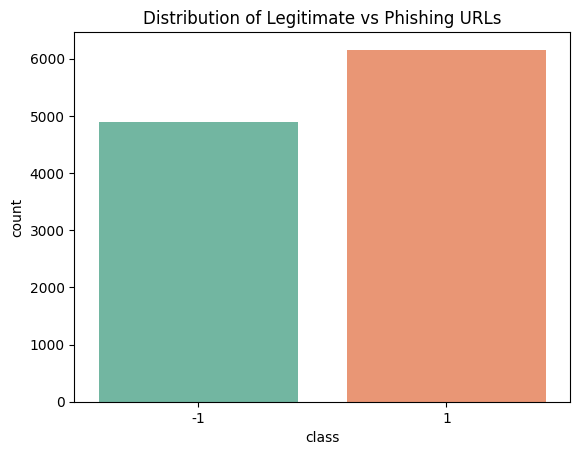

```python
# @title
import matplotlib.pyplot as plt
import seaborn as sns

# Class distribution
sns.countplot(x='class', data=data, palette='Set2')
plt.title('Distribution of Legitimate vs Phishing URLs')
plt.show()
```

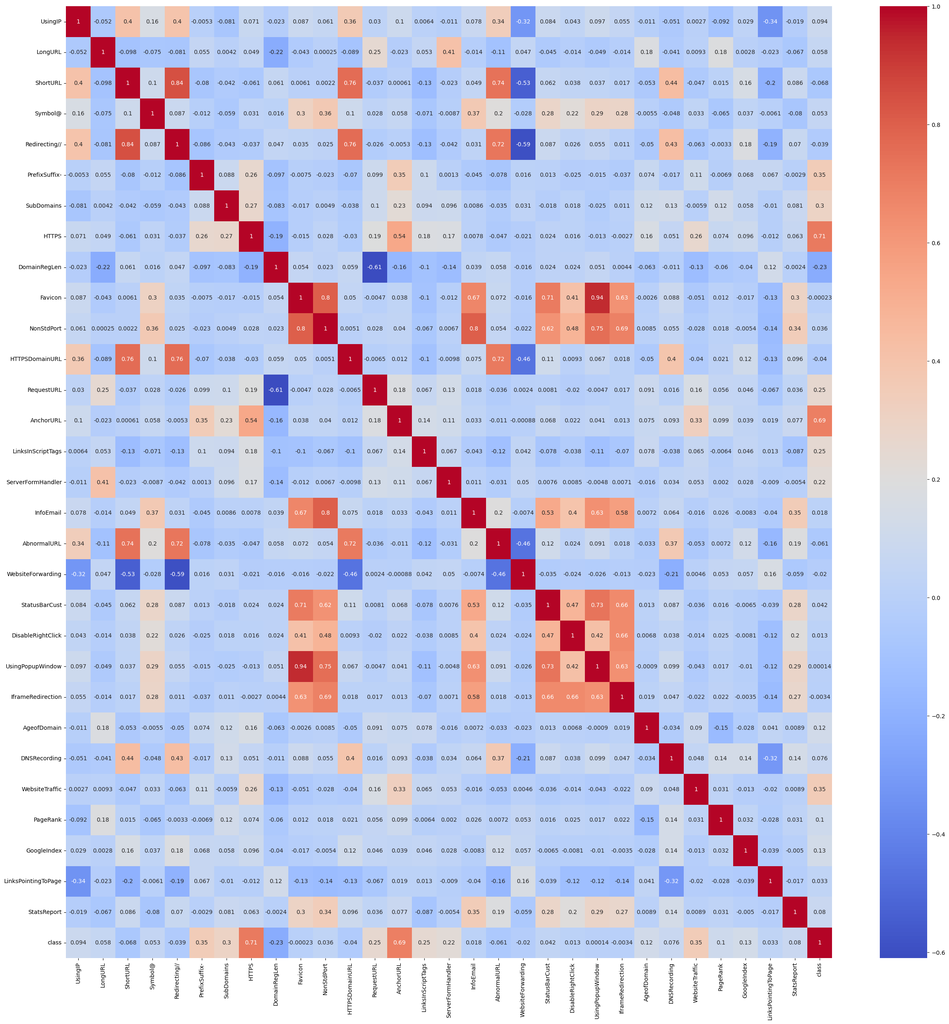

```python
# @title
#Correlation heatmap

plt.figure(figsize=(30,30))
sns.heatmap(data.corr(), cmap='coolwarm' , annot=True)
plt.show()
```

## Feature Importance (Based on Classification)

#### Visualization: Bar chart

#### Purpose: Visualize which features are most important for distinguishing between phishing and legitimate URLs, using a classification model.

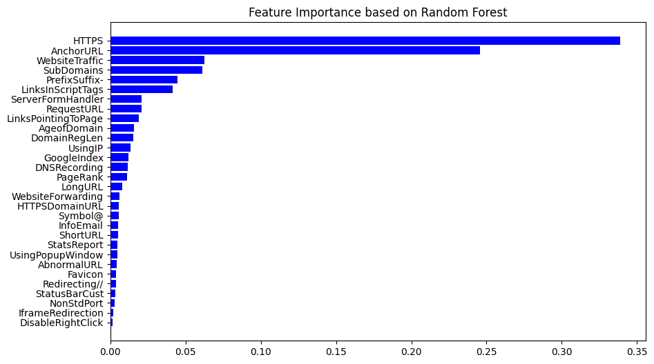

```python
# @title
from sklearn.ensemble import RandomForestClassifier

X = data.drop(columns=['class'])  # Replace 'target' with your actual target column name
y = data['class']

# Assume 'X' is the features and 'y' is the target
model = RandomForestClassifier()
model.fit(X, y)

feature_importance = model.feature_importances_
sorted_idx = np.argsort(feature_importance)

plt.figure(figsize=(10, 6))
plt.barh(data.columns[sorted_idx], feature_importance[sorted_idx], color='b')
plt.title('Feature Importance based on Random Forest')
plt.show()
```

## Boxplots for Numerical Features

#### Visualization: Boxplots

#### Purpose: Examine the distribution of key numerical features (like WebsiteTraffic, DomainRegLen) across legitimate and phishing URLs.

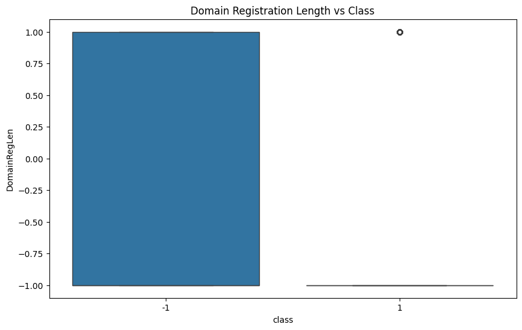

```python
# @title
plt.figure(figsize=(10, 6))
sns.boxplot(x='class', y='DomainRegLen', data=data)
plt.title('Domain Registration Length vs Class')
plt.show()
```

## Visualization: Boxplot

#### Purpose: Analyze how website traffic differs between phishing and legitimate sites.

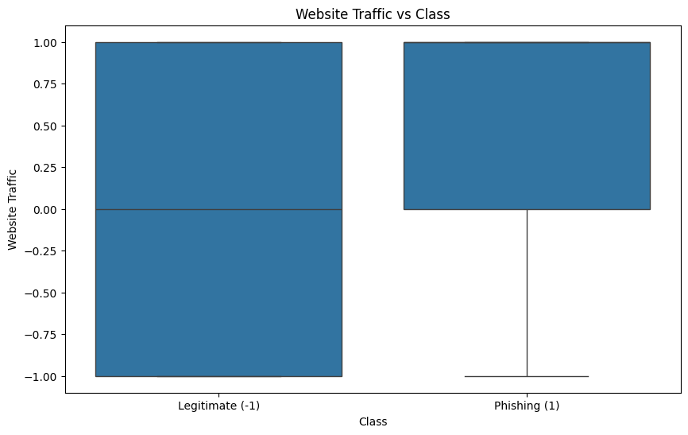

```python
# @title
plt.figure(figsize=(10, 6))
sns.boxplot(x='class', y='WebsiteTraffic', data=data)
plt.title('Website Traffic vs Class')
plt.xlabel('Class')
plt.ylabel('Website Traffic')
plt.xticks([0, 1], ['Legitimate (-1)', 'Phishing (1)'])
plt.show()
```

## Count of Short URLs vs. Long URLs

#### Visualization: Bar chart

#### Purpose: Compare the frequency of short URLs and long URLs in phishing and legitimate websites.

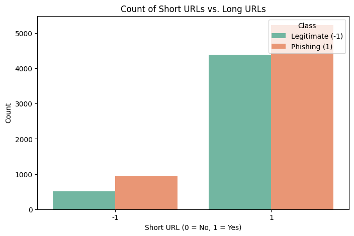

```python
# @title
plt.figure(figsize=(8, 5))
sns.countplot(x='ShortURL', hue='class', data=data, palette='Set2')
plt.title('Count of Short URLs vs. Long URLs')
plt.xlabel('Short URL (0 = No, 1 = Yes)')
plt.ylabel('Count')
plt.legend(title='Class', loc='upper right', labels=['Legitimate (-1)', 'Phishing (1)'])
plt.show()
```

## Feature Distributions for Phishing vs. Legitimate

#### Visualization: Overlay histograms

#### Purpose: Show the distributions of key features for both classes side by side for comparison.

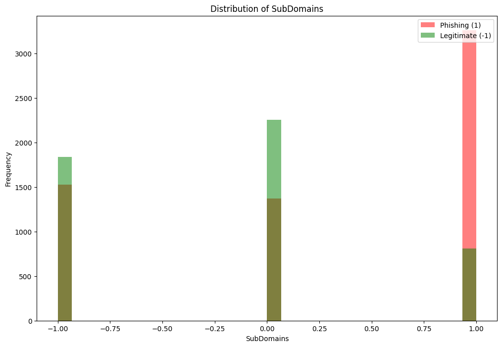

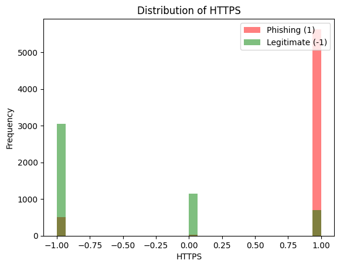

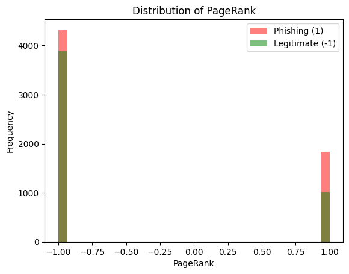

```python
# @title
plt.figure(figsize=(12, 8))
for feature in ['SubDomains', 'HTTPS', 'PageRank']:
    plt.hist(data[data['class'] == 1][feature], alpha=0.5, bins=30, label='Phishing (1)', color='r')
    plt.hist(data[data['class'] == -1][feature], alpha=0.5, bins=30, label='Legitimate (-1)', color='g')
    plt.title(f'Distribution of {feature}')
    plt.xlabel(feature)
    plt.ylabel('Frequency')
    plt.legend(loc='upper right')
    plt.show()
```

## Visualization: Pairplot (with KDE)

#### Purpose: Visualize the distribution and relationships of multiple features simultaneously for phishing and legitimate URLs.

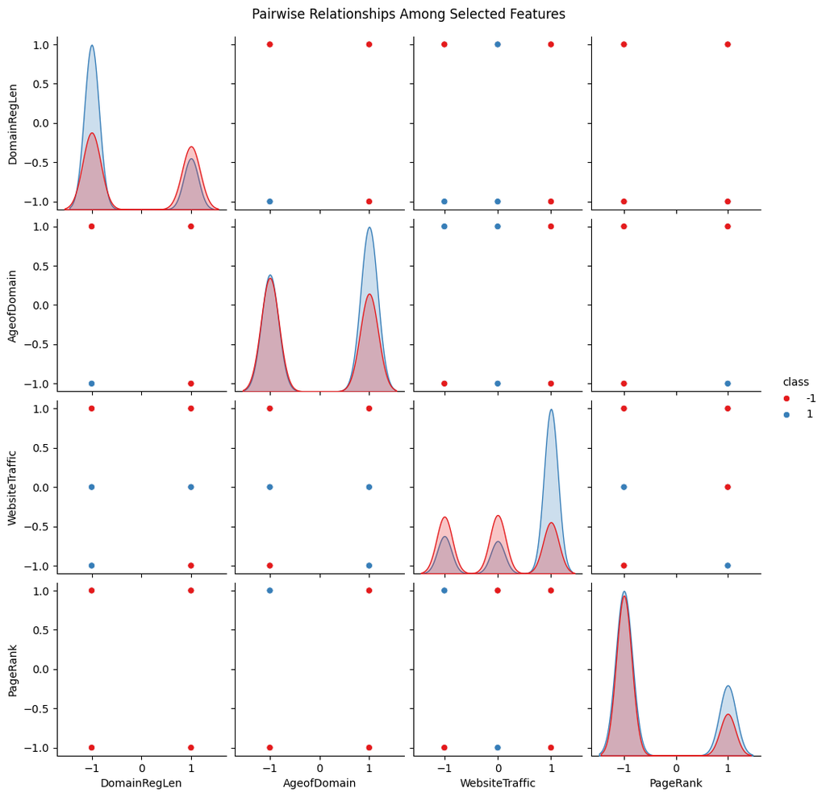

```python
# @title
features_to_plot = ['DomainRegLen', 'AgeofDomain', 'WebsiteTraffic', 'PageRank', 'class']
sns.pairplot(data[features_to_plot], hue='class', palette='Set1', diag_kind='kde')
plt.suptitle('Pairwise Relationships Among Selected Features', y=1.02)
plt.show()
```

#### Visualization: Scatter plot

#### Purpose: Explore the relationship between website traffic and class label

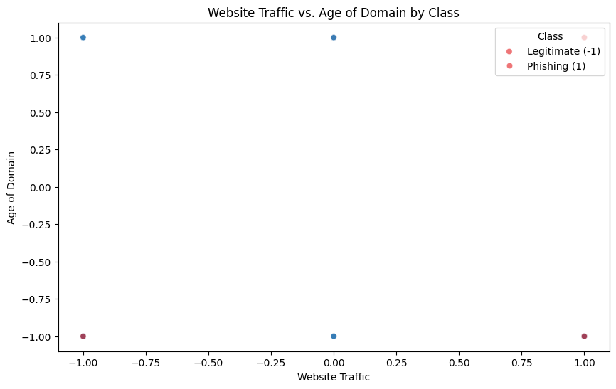

```python
# @title
plt.figure(figsize=(10, 6))
sns.scatterplot(x='WebsiteTraffic', y='AgeofDomain', hue='class', data=data, palette='Set1', alpha=0.6)
plt.title('Website Traffic vs. Age of Domain by Class')
plt.xlabel('Website Traffic')
plt.ylabel('Age of Domain')
plt.legend(title='Class', loc='upper right', labels=['Legitimate (-1)', 'Phishing (1)'])
plt.show()
```

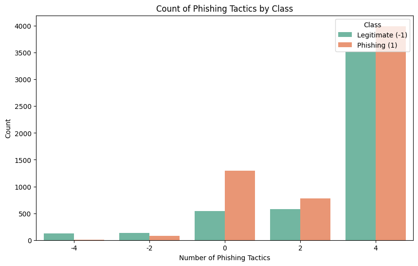

```python
# @title
tactics_features = ['UsingPopupWindow', 'IframeRedirection', 'AbnormalURL', 'Redirecting//']
data['Phishing_Tactics'] = data[tactics_features].sum(axis=1)

plt.figure(figsize=(10, 6))
sns.countplot(x='Phishing_Tactics', hue='class', data=data, palette='Set2')
plt.title('Count of Phishing Tactics by Class')
plt.xlabel('Number of Phishing Tactics')
plt.ylabel('Count')
plt.legend(title='Class', loc='upper right', labels=['Legitimate (-1)', 'Phishing (1)'])
plt.show()
```

## 4. Splitting the Data:

The data is split into train & test sets, 80-20 split.

```python
# @title
# Splitting the dataset into dependant and independant fetature
X = data.drop(["class"],axis =1)
y = data["class"]
```

```python
# @title
# Splitting the dataset into train and test sets: 80-20 split
from sklearn.model_selection import train_test_split
X_train, X_test, y_train, y_test = train_test_split(X, y, test_size = 0.2, random_state = 42)

# Print the shapes of the datasets
print("Shapes of the datasets:")
print(f"Training features (X_train): {X_train.shape}")
print(f"Training labels (y_train): {y_train.shape}")
print(f"Testing features (X_test): {X_test.shape}")
print(f"Testing labels (y_test): {y_test.shape}")
```

```
Shapes of the datasets:
Training features (X_train): (8843, 31)
Training labels (y_train): (8843,)
Testing features (X_test): (2211, 31)
Testing labels (y_test): (2211,)
```

# Visualizing Model Performance: Accuracy, Confusion Matrix, and Classification Reports

```python
# @title
import matplotlib.pyplot as plt
import numpy as np
from sklearn.metrics import confusion_matrix, accuracy_score, f1_score, classification_report
import seaborn as sns

def plot_confusion_matrix(y_true, y_pred, model_name):
    cm = confusion_matrix(y_true, y_pred)
    plt.figure(figsize=(6,4))
    sns.heatmap(cm, annot=True, fmt="d", cmap="Blues")
    plt.title(f'Confusion Matrix for {model_name}')
    plt.ylabel('Actual Label')
    plt.xlabel('Predicted Label')
    plt.show()

# Dummy lists for storing accuracies
train_accuracies = []
test_accuracies = []

# Function to plot training vs testing accuracy
def plot_training_vs_testing(train_accuracies, test_accuracies, model_name):
    epochs = np.arange(1, len(train_accuracies)+1)
    plt.figure(figsize=(8,6))
    plt.plot(epochs, train_accuracies, label='Training Accuracy')
    plt.plot(epochs, test_accuracies, label='Testing Accuracy')
    plt.title(f'Training vs Testing Accuracy for {model_name}')
    plt.xlabel('Iterations')
    plt.ylabel('Accuracy')
    plt.legend()
    plt.show()

def print_classification_report(y_true, y_pred, model_name):
    print(f"Classification Report for {model_name}:")
    print(classification_report(y_true, y_pred))
```

# BaggingClassifier, VotingClassifier , AdaBoostClassifier

# DecisionTreeClassifier

```
X_train shape: (8843, 31)
y_train shape: (8843,)
X_test shape: (2211, 31)
y_test shape: (2211,)
```

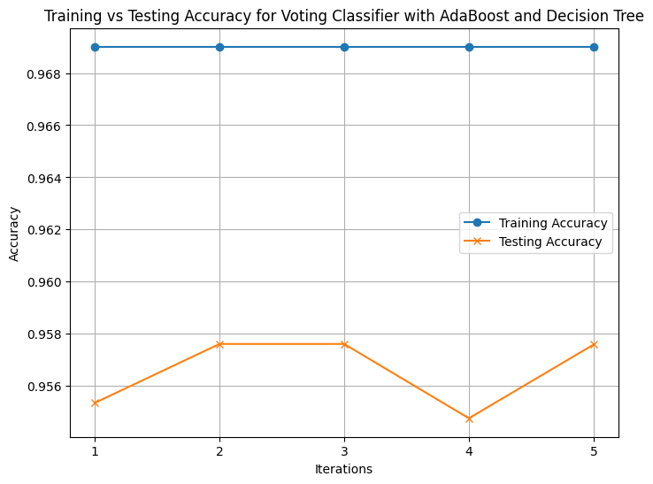

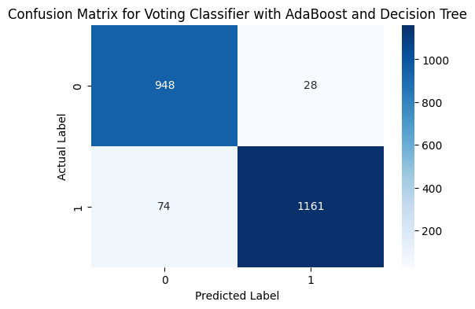

```
Classification Report for Voting Classifier with AdaBoost and Decision Tree:
              precision    recall  f1-score   support

          -1       0.93      0.97      0.95       976
           1       0.98      0.94      0.96      1235

    accuracy                           0.95      2211
   macro avg       0.95      0.96      0.95      2211
weighted avg       0.95      0.95      0.95      2211
```

```python
# @title
# Import necessary libraries
import numpy as np
import matplotlib.pyplot as plt
import seaborn as sns
from sklearn.model_selection import train_test_split, cross_val_score
from sklearn.ensemble import BaggingClassifier, VotingClassifier, AdaBoostClassifier
from sklearn.tree import DecisionTreeClassifier
from sklearn.metrics import confusion_matrix, classification_report

# Assume X and y are defined and preprocessed
# X: feature set (shape: (11054, 31))
# y: labels (shape: (11054,))

# Splitting the dataset into train and test sets: 80-20 split
X_train, X_test, y_train, y_test = train_test_split(X, y, test_size=0.2, random_state=42)

# Check input shapes
print("X_train shape:", X_train.shape)
print("y_train shape:", y_train.shape)
print("X_test shape:", X_test.shape)
print("y_test shape:", y_test.shape)

# Create individual models
decision_tree_model = DecisionTreeClassifier(random_state=42)
adaboost_model = AdaBoostClassifier(n_estimators=100, random_state=42)

# Create a BaggingClassifier for Decision Tree
bagging_decision_tree_model = BaggingClassifier(estimator=decision_tree_model, n_estimators=100, random_state=42)

# Create a BaggingClassifier for AdaBoost
bagging_adaboost_model = BaggingClassifier(estimator=adaboost_model, n_estimators=100, random_state=42)

# Create a VotingClassifier that combines both models using hard voting
voting_model = VotingClassifier(estimators=[
    ('bagging_decision_tree', bagging_decision_tree_model),
    ('bagging_adaboost', bagging_adaboost_model)
], voting='hard')

# Perform cross-validation to get training and test accuracy scores for the VotingClassifier
cv_scores = cross_val_score(voting_model, X_train, y_train, cv=5)

# Fit the VotingClassifier with the models
voting_model.fit(X_train, y_train)

# Calculate train accuracy
train_accuracy = voting_model.score(X_train, y_train)

# Function to plot training vs testing accuracy
def plot_training_vs_testing(train_accuracy, test_accuracies, model_name):
    epochs = np.arange(1, len(test_accuracies) + 1)
    plt.figure(figsize=(8, 6))
    plt.plot(epochs, [train_accuracy] * len(test_accuracies), label='Training Accuracy', marker='o')
    plt.plot(epochs, test_accuracies, label='Testing Accuracy', marker='x')
    plt.title(f'Training vs Testing Accuracy for {model_name}')
    plt.xlabel('Iterations')
    plt.ylabel('Accuracy')
    plt.xticks(epochs)
    plt.legend()
    plt.grid()
    plt.show()

# Function to plot confusion matrix
def plot_confusion_matrix(y_true, y_pred, model_name):
    cm = confusion_matrix(y_true, y_pred)
    plt.figure(figsize=(6, 4))
    sns.heatmap(cm, annot=True, fmt="d", cmap="Blues")
    plt.title(f'Confusion Matrix for {model_name}')
    plt.ylabel('Actual Label')
    plt.xlabel('Predicted Label')
    plt.show()

# Function to print classification report
def print_classification_report(y_true, y_pred, model_name):
    print(f"Classification Report for {model_name}:")
    print(classification_report(y_true, y_pred))

# Plot the accuracy graphs for the VotingClassifier
plot_training_vs_testing(train_accuracy, cv_scores, "Voting Classifier with AdaBoost and Decision Tree")

# Make predictions on the test set and plot confusion matrix
voting_predictions = voting_model.predict(X_test)
plot_confusion_matrix(y_test, voting_predictions, "Voting Classifier with AdaBoost and Decision Tree")

# Print the classification report for the VotingClassifier
print_classification_report(y_test, voting_predictions, "Voting Classifier with AdaBoost and Decision Tree")
```

# voting='soft'

```
X_train shape: (8843, 31)
y_train shape: (8843,)
X_test shape: (2211, 31)
y_test shape: (2211,)
```

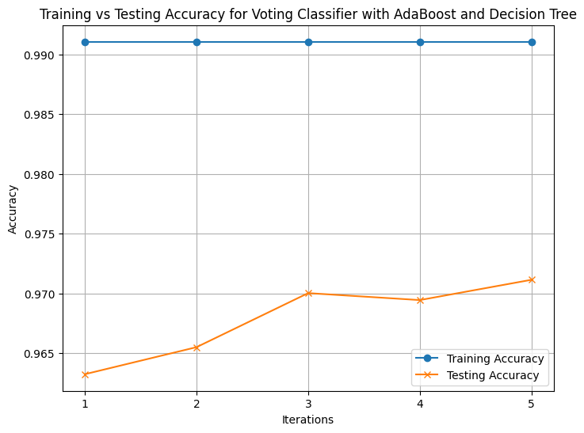

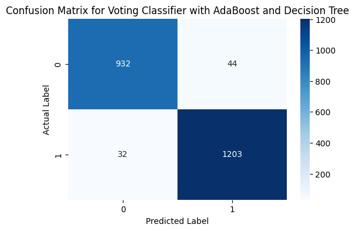

```
Classification Report for Voting Classifier with AdaBoost and Decision Tree:
              precision    recall  f1-score   support

          -1       0.97      0.95      0.96       976
           1       0.96      0.97      0.97      1235

    accuracy                           0.97      2211
   macro avg       0.97      0.96      0.97      2211
weighted avg       0.97      0.97      0.97      2211
```

```python
# @title
# Import necessary libraries
import numpy as np
import matplotlib.pyplot as plt
import seaborn as sns
from sklearn.model_selection import train_test_split, cross_val_score
from sklearn.ensemble import BaggingClassifier, VotingClassifier, AdaBoostClassifier
from sklearn.tree import DecisionTreeClassifier
from sklearn.metrics import confusion_matrix, classification_report

# Assume X and y are defined and preprocessed
# X: feature set (shape: (11054, 31))
# y: labels (shape: (11054,))

# Splitting the dataset into train and test sets: 80-20 split
X_train, X_test, y_train, y_test = train_test_split(X, y, test_size=0.2, random_state=42)

# Check input shapes
print("X_train shape:", X_train.shape)
print("y_train shape:", y_train.shape)
print("X_test shape:", X_test.shape)
print("y_test shape:", y_test.shape)

# Create individual models
decision_tree_model = DecisionTreeClassifier(random_state=42)
adaboost_model = AdaBoostClassifier(n_estimators=100, random_state=42)

# Create a BaggingClassifier for Decision Tree
bagging_decision_tree_model = BaggingClassifier(estimator=decision_tree_model, n_estimators=100, random_state=42)

# Create a BaggingClassifier for AdaBoost
bagging_adaboost_model = BaggingClassifier(estimator=adaboost_model, n_estimators=100, random_state=42)

# Create a VotingClassifier that combines both models using hard voting
voting_model = VotingClassifier(estimators=[
    ('bagging_decision_tree', bagging_decision_tree_model),
    ('bagging_adaboost', bagging_adaboost_model)
], voting='soft')

# Perform cross-validation to get training and test accuracy scores for the VotingClassifier
cv_scores = cross_val_score(voting_model, X_train, y_train, cv=5)

# Fit the VotingClassifier with the models
voting_model.fit(X_train, y_train)

# Calculate train accuracy
train_accuracy = voting_model.score(X_train, y_train)

# Function to plot training vs testing accuracy
def plot_training_vs_testing(train_accuracy, test_accuracies, model_name):
    epochs = np.arange(1, len(test_accuracies) + 1)
    plt.figure(figsize=(8, 6))
    plt.plot(epochs, [train_accuracy] * len(test_accuracies), label='Training Accuracy', marker='o')
    plt.plot(epochs, test_accuracies, label='Testing Accuracy', marker='x')
    plt.title(f'Training vs Testing Accuracy for {model_name}')
    plt.xlabel('Iterations')
    plt.ylabel('Accuracy')
    plt.xticks(epochs)
    plt.legend()
    plt.grid()
    plt.show()

# Function to plot confusion matrix
def plot_confusion_matrix(y_true, y_pred, model_name):
    cm = confusion_matrix(y_true, y_pred)
    plt.figure(figsize=(6, 4))
    sns.heatmap(cm, annot=True, fmt="d", cmap="Blues")
    plt.title(f'Confusion Matrix for {model_name}')
    plt.ylabel('Actual Label')
    plt.xlabel('Predicted Label')
    plt.show()

# Function to print classification report
def print_classification_report(y_true, y_pred, model_name):
    print(f"Classification Report for {model_name}:")
    print(classification_report(y_true, y_pred))

# Plot the accuracy graphs for the VotingClassifier
plot_training_vs_testing(train_accuracy, cv_scores, "Voting Classifier with AdaBoost and Decision Tree")

# Make predictions on the test set and plot confusion matrix
voting_predictions = voting_model.predict(X_test)
plot_confusion_matrix(y_test, voting_predictions, "Voting Classifier with AdaBoost and Decision Tree")

# Print the classification report for the VotingClassifier
print_classification_report(y_test, voting_predictions, "Voting Classifier with AdaBoost and Decision Tree")
```

# Best parameters

```
X_train shape: (8843, 31)
y_train shape: (8843,)
X_test shape: (2211, 31)
y_test shape: (2211,)
Best parameters: {'bagging_adaboost__n_estimators': 50, 'bagging_decision_tree__n_estimators': 50}
```

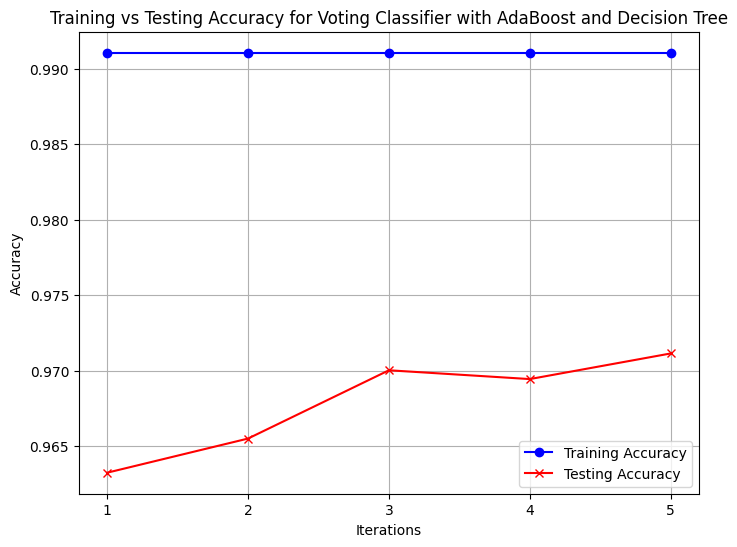

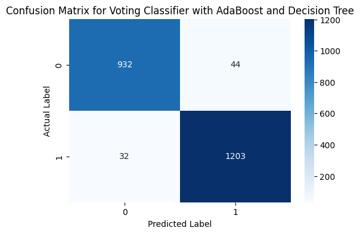

```
Classification Report for Voting Classifier with AdaBoost and Decision Tree:
              precision    recall  f1-score   support

          -1       0.97      0.95      0.96       976
           1       0.96      0.97      0.97      1235

    accuracy                           0.97      2211
   macro avg       0.97      0.96      0.97      2211
weighted avg       0.97      0.97      0.97      2211
```

```python
# @title
# Import necessary libraries
import numpy as np
import matplotlib.pyplot as plt
import seaborn as sns
from sklearn.model_selection import train_test_split, cross_val_score
from sklearn.ensemble import BaggingClassifier, VotingClassifier, AdaBoostClassifier
from sklearn.tree import DecisionTreeClassifier
from sklearn.metrics import confusion_matrix, classification_report
from sklearn.model_selection import GridSearchCV


X_train, X_test, y_train, y_test = train_test_split(X, y, test_size=0.2, random_state=42)

# Check input shapes
print("X_train shape:", X_train.shape)
print("y_train shape:", y_train.shape)
print("X_test shape:", X_test.shape)
print("y_test shape:", y_test.shape)

# Create individual models
decision_tree_model = DecisionTreeClassifier(random_state=42)
adaboost_model = AdaBoostClassifier(n_estimators=100, random_state=42)

# Create a BaggingClassifier for Decision Tree
bagging_decision_tree_model = BaggingClassifier(estimator=decision_tree_model, n_estimators=100, random_state=42)

# Create a BaggingClassifier for AdaBoost
bagging_adaboost_model = BaggingClassifier(estimator=adaboost_model, n_estimators=100, random_state=42)

# Create a VotingClassifier that combines both models using soft voting
voting_model = VotingClassifier(estimators=[
    ('bagging_decision_tree', bagging_decision_tree_model),
    ('bagging_adaboost', bagging_adaboost_model)
], voting='soft')

# Perform cross-validation to get training and test accuracy scores for the VotingClassifier
cv_scores = cross_val_score(voting_model, X_train, y_train, cv=5)

# Fit the VotingClassifier with the models
voting_model.fit(X_train, y_train)

# Calculate train accuracy
train_accuracy = voting_model.score(X_train, y_train)

# Calculate test accuracy after fitting
test_accuracy = voting_model.score(X_test, y_test)

# Hyperparameter tuning using GridSearchCV for Decision Tree Classifier
param_grid = {
    'bagging_decision_tree__n_estimators': range(50, 151, 25),  # Try different numbers of estimators for bagging
    'bagging_adaboost__n_estimators': range(50, 151, 25)  # Different estimators for AdaBoost
}

grid_search = GridSearchCV(estimator=voting_model, param_grid=param_grid, cv=3)
grid_search.fit(X_train, y_train)

# Best parameters from grid search
print("Best parameters:", grid_search.best_params_)

# Function to plot training vs testing accuracy over multiple iterations
def plot_training_vs_testing(train_accuracies, test_accuracies, model_name):
    epochs = np.arange(1, len(test_accuracies) + 1)

    # Check if train_accuracies is a list, if not make it repeat the same training accuracy across epochs
    if isinstance(train_accuracies, (int, float)):
        train_accuracies = [train_accuracies] * len(test_accuracies)

    plt.figure(figsize=(8, 6))
    plt.plot(epochs, train_accuracies, label='Training Accuracy', marker='o', color='blue')
    plt.plot(epochs, test_accuracies, label='Testing Accuracy', marker='x', color='red')

    plt.title(f'Training vs Testing Accuracy for {model_name}')
    plt.xlabel('Iterations')
    plt.ylabel('Accuracy')
    plt.xticks(epochs)
    plt.legend(loc='best')
    plt.grid()
    plt.show()

# Function to plot confusion matrix
def plot_confusion_matrix(y_true, y_pred, model_name):
    cm = confusion_matrix(y_true, y_pred)
    plt.figure(figsize=(6, 4))
    sns.heatmap(cm, annot=True, fmt="d", cmap="Blues")
    plt.title(f'Confusion Matrix for {model_name}')
    plt.ylabel('Actual Label')
    plt.xlabel('Predicted Label')
    plt.show()

# Function to print classification report
def print_classification_report(y_true, y_pred, model_name):
    print(f"Classification Report for {model_name}:")
    print(classification_report(y_true, y_pred))

# Plot the accuracy graphs for the VotingClassifier
plot_training_vs_testing(train_accuracy, cv_scores, "Voting Classifier with AdaBoost and Decision Tree")

# Make predictions on the test set and plot confusion matrix
voting_predictions = voting_model.predict(X_test)
plot_confusion_matrix(y_test, voting_predictions, "Voting Classifier with AdaBoost and Decision Tree")

# Print the classification report for the VotingClassifier
print_classification_report(y_test, voting_predictions, "Voting Classifier with AdaBoost and Decision Tree")
```

```python
!pandoc --version
```

[output not shown]

```python
!pip install pypandoc
```

```python
!pandoc --version
```

[output not shown]